# Risk Factor Analysis

## Outcome Variable

**Outcome Variable:** haz

## Predictor Variables

**Intervention Variable:** mbmi

**Adjustment Set:**

- arm
- W_mage
- W_fage
- meducyrs
- feducyrs
- single
- brthmon
- W_gagebrth
- W_birthwt
- W_birthlen
- vagbrth
- delta_W_mage
- delta_W_fage
- delta_meducyrs
- delta_feducyrs
- delta_single
- delta_brthmon
- delta_W_gagebrth
- delta_W_birthwt
- delta_W_birthlen
- delta_vagbrth

## Stratifying Variables

The analysis was stratified on these variable(s):

- agecat
- studyid
- country

## Data Summary

| agecat | studyid | country | mbmi | n_cell | n |
| --- | --- | --- | --- | --- | --- |
| 6 months | LCNI-5 | MALAWI | Normal weight | 691 | 836 |
| 6 months | LCNI-5 | MALAWI | Underweight | 145 | 836 |
| 6 months | MAL-ED | BANGLADESH | Normal weight | 209 | 241 |
| 6 months | MAL-ED | BANGLADESH | Underweight | 32 | 241 |
| 6 months | MAL-ED | BRAZIL | Normal weight | 199 | 208 |
| 6 months | MAL-ED | BRAZIL | Underweight | 9 | 208 |
| 6 months | MAL-ED | INDIA | Normal weight | 186 | 235 |
| 6 months | MAL-ED | INDIA | Underweight | 49 | 235 |
| 6 months | MAL-ED | NEPAL | Normal weight | 236 | 236 |
| 6 months | MAL-ED | NEPAL | Underweight | 0 | 236 |
| 6 months | MAL-ED | PERU | Normal weight | 267 | 272 |
| 6 months | MAL-ED | PERU | Underweight | 5 | 272 |
| 6 months | MAL-ED | SOUTH AFRICA | Normal weight | 242 | 249 |
| 6 months | MAL-ED | SOUTH AFRICA | Underweight | 7 | 249 |
| 6 months | MAL-ED | TANZANIA, UNITED REPUBLIC OF | Normal weight | 233 | 247 |
| 6 months | MAL-ED | TANZANIA, UNITED REPUBLIC OF | Underweight | 14 | 247 |
| 6 months | NIH-Birth | BANGLADESH | Normal weight | 444 | 537 |
| 6 months | NIH-Birth | BANGLADESH | Underweight | 93 | 537 |
| 6 months | NIH-Crypto | BANGLADESH | Normal weight | 648 | 715 |
| 6 months | NIH-Crypto | BANGLADESH | Underweight | 67 | 715 |
| 6 months | PROBIT | BELARUS | Normal weight | 12520 | 13025 |
| 6 months | PROBIT | BELARUS | Underweight | 505 | 13025 |
| 6 months | PROVIDE | BANGLADESH | Normal weight | 498 | 603 |
| 6 months | PROVIDE | BANGLADESH | Underweight | 105 | 603 |
| 6 months | SAS-CompFeed | INDIA | Normal weight | 922 | 1227 |
| 6 months | SAS-CompFeed | INDIA | Underweight | 305 | 1227 |
| 6 months | TanzaniaChild2 | TANZANIA, UNITED REPUBLIC OF | Normal weight | 1949 | 1983 |
| 6 months | TanzaniaChild2 | TANZANIA, UNITED REPUBLIC OF | Underweight | 34 | 1983 |
| 6 months | ZVITAMBO | ZIMBABWE | Normal weight | 6999 | 7375 |
| 6 months | ZVITAMBO | ZIMBABWE | Underweight | 376 | 7375 |
| 24 months | LCNI-5 | MALAWI | Normal weight | 482 | 577 |
| 24 months | LCNI-5 | MALAWI | Underweight | 95 | 577 |
| 24 months | MAL-ED | BANGLADESH | Normal weight | 183 | 212 |
| 24 months | MAL-ED | BANGLADESH | Underweight | 29 | 212 |
| 24 months | MAL-ED | BRAZIL | Normal weight | 162 | 168 |
| 24 months | MAL-ED | BRAZIL | Underweight | 6 | 168 |
| 24 months | MAL-ED | INDIA | Normal weight | 180 | 226 |
| 24 months | MAL-ED | INDIA | Underweight | 46 | 226 |
| 24 months | MAL-ED | NEPAL | Normal weight | 228 | 228 |
| 24 months | MAL-ED | NEPAL | Underweight | 0 | 228 |
| 24 months | MAL-ED | PERU | Normal weight | 197 | 201 |
| 24 months | MAL-ED | PERU | Underweight | 4 | 201 |
| 24 months | MAL-ED | SOUTH AFRICA | Normal weight | 227 | 234 |
| 24 months | MAL-ED | SOUTH AFRICA | Underweight | 7 | 234 |
| 24 months | MAL-ED | TANZANIA, UNITED REPUBLIC OF | Normal weight | 203 | 214 |
| 24 months | MAL-ED | TANZANIA, UNITED REPUBLIC OF | Underweight | 11 | 214 |
| 24 months | NIH-Birth | BANGLADESH | Normal weight | 349 | 429 |
| 24 months | NIH-Birth | BANGLADESH | Underweight | 80 | 429 |
| 24 months | NIH-Crypto | BANGLADESH | Normal weight | 471 | 514 |
| 24 months | NIH-Crypto | BANGLADESH | Underweight | 43 | 514 |
| 24 months | PROBIT | BELARUS | Normal weight | 3863 | 4005 |
| 24 months | PROBIT | BELARUS | Underweight | 142 | 4005 |
| 24 months | PROVIDE | BANGLADESH | Normal weight | 477 | 577 |
| 24 months | PROVIDE | BANGLADESH | Underweight | 100 | 577 |
| 24 months | TanzaniaChild2 | TANZANIA, UNITED REPUBLIC OF | Normal weight | 6 | 6 |
| 24 months | TanzaniaChild2 | TANZANIA, UNITED REPUBLIC OF | Underweight | 0 | 6 |
| 24 months | ZVITAMBO | ZIMBABWE | Normal weight | 1312 | 1373 |
| 24 months | ZVITAMBO | ZIMBABWE | Underweight | 61 | 1373 |

The following strata were considered:

- agecat: 24 months, studyid: LCNI-5, country: MALAWI
- agecat: 24 months, studyid: MAL-ED, country: BANGLADESH
- agecat: 24 months, studyid: MAL-ED, country: BRAZIL
- agecat: 24 months, studyid: MAL-ED, country: INDIA
- agecat: 24 months, studyid: MAL-ED, country: NEPAL
- agecat: 24 months, studyid: MAL-ED, country: PERU
- agecat: 24 months, studyid: MAL-ED, country: SOUTH AFRICA
- agecat: 24 months, studyid: MAL-ED, country: TANZANIA, UNITED REPUBLIC OF
- agecat: 24 months, studyid: NIH-Birth, country: BANGLADESH
- agecat: 24 months, studyid: NIH-Crypto, country: BANGLADESH
- agecat: 24 months, studyid: PROBIT, country: BELARUS
- agecat: 24 months, studyid: PROVIDE, country: BANGLADESH
- agecat: 24 months, studyid: TanzaniaChild2, country: TANZANIA, UNITED REPUBLIC OF
- agecat: 24 months, studyid: ZVITAMBO, country: ZIMBABWE
- agecat: 6 months, studyid: LCNI-5, country: MALAWI
- agecat: 6 months, studyid: MAL-ED, country: BANGLADESH
- agecat: 6 months, studyid: MAL-ED, country: BRAZIL
- agecat: 6 months, studyid: MAL-ED, country: INDIA
- agecat: 6 months, studyid: MAL-ED, country: NEPAL
- agecat: 6 months, studyid: MAL-ED, country: PERU
- agecat: 6 months, studyid: MAL-ED, country: SOUTH AFRICA
- agecat: 6 months, studyid: MAL-ED, country: TANZANIA, UNITED REPUBLIC OF
- agecat: 6 months, studyid: NIH-Birth, country: BANGLADESH
- agecat: 6 months, studyid: NIH-Crypto, country: BANGLADESH
- agecat: 6 months, studyid: PROBIT, country: BELARUS
- agecat: 6 months, studyid: PROVIDE, country: BANGLADESH
- agecat: 6 months, studyid: SAS-CompFeed, country: INDIA
- agecat: 6 months, studyid: TanzaniaChild2, country: TANZANIA, UNITED REPUBLIC OF
- agecat: 6 months, studyid: ZVITAMBO, country: ZIMBABWE

### Dropped Strata

Some strata were dropped due to rare outcomes:

- agecat: 6 months, studyid: MAL-ED, country: NEPAL
- agecat: 24 months, studyid: MAL-ED, country: NEPAL
- agecat: 24 months, studyid: MAL-ED, country: PERU
- agecat: 24 months, studyid: TanzaniaChild2, country: TANZANIA, UNITED REPUBLIC OF

## Methods Detail

We’re interested in the causal parameters $E[Y_a]$ for all values of $a \in \mathcal{A}$. These parameters represent the mean outcome if, possibly contrary to fact, we intervened to set all units to have $A=a$. Under the randomization and positivity assumptions, these are identified by the statistical parameters $\psi_a=E_W[E_{Y|A,W}(Y|A=a,W)]$. In addition, we’re interested in the mean of $Y$, $E[Y]$ under no intervention (the observed mean). We will estimate these parameters by using SuperLearner to fit the relevant likelihood factors – $E_{Y|A,W}(Y|A=a,W)$ and $p(A=a|W)$, and then updating our likelihood fit using a joint TMLE.

For unadjusted analyses ($W=\{\}$), initial likelihoods were estimated using Lrnr_glm to estimate the simple $E(Y|A)$ and Lrnr_mean to estimate $p(A)$. For adjusted analyses, a small library containing Lrnr_glmnet, Lrnr_xgboost, and Lrnr_mean was used.

Having estimated these parameters, we will then use the delta method to estimate relative risks and attributable risks relative to a prespecified baseline level of $A$.

# Results Detail

## Results Plots

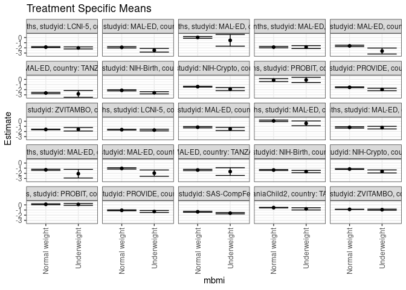

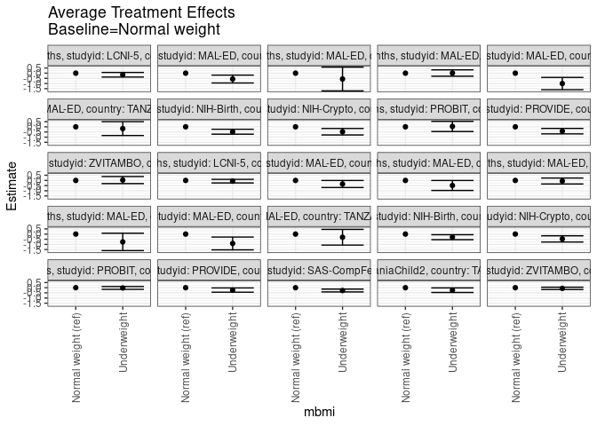

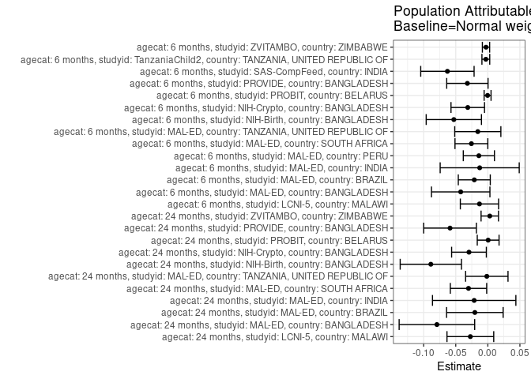

## Results Table

### Parameter: TSM

| agecat | studyid | country | intervention_level | baseline_level | estimate | ci_lower | ci_upper |
| --- | --- | --- | --- | --- | --- | --- | --- |
| 6 months | LCNI-5 | MALAWI | Normal weight | NA | -1.6447419 | -1.7227308 | -1.5667531 |
| 6 months | LCNI-5 | MALAWI | Underweight | NA | -1.7147311 | -1.8689734 | -1.5604888 |
| 6 months | MAL-ED | BANGLADESH | Normal weight | NA | -1.1627355 | -1.2887047 | -1.0367664 |
| 6 months | MAL-ED | BANGLADESH | Underweight | NA | -1.5081470 | -1.8250245 | -1.1912695 |
| 6 months | MAL-ED | BRAZIL | Normal weight | NA | 0.0708375 | -0.0781476 | 0.2198227 |
| 6 months | MAL-ED | BRAZIL | Underweight | NA | -0.4164815 | -0.8769172 | 0.0439543 |
| 6 months | MAL-ED | INDIA | Normal weight | NA | -1.1932992 | -1.3261133 | -1.0604852 |
| 6 months | MAL-ED | INDIA | Underweight | NA | -1.2481329 | -1.5040394 | -0.9922265 |
| 6 months | MAL-ED | PERU | Normal weight | NA | -1.3101467 | -1.4185443 | -1.2017491 |
| 6 months | MAL-ED | PERU | Underweight | NA | -2.0693333 | -2.9031517 | -1.2355150 |
| 6 months | MAL-ED | SOUTH AFRICA | Normal weight | NA | -1.0471625 | -1.1780920 | -0.9162331 |
| 6 months | MAL-ED | SOUTH AFRICA | Underweight | NA | -1.9571429 | -2.5636947 | -1.3505910 |
| 6 months | MAL-ED | TANZANIA, UNITED REPUBLIC OF | Normal weight | NA | -1.3531346 | -1.4771308 | -1.2291383 |
| 6 months | MAL-ED | TANZANIA, UNITED REPUBLIC OF | Underweight | NA | -1.6603443 | -2.4120710 | -0.9086176 |
| 6 months | NIH-Birth | BANGLADESH | Normal weight | NA | -1.3544103 | -1.4495573 | -1.2592633 |
| 6 months | NIH-Birth | BANGLADESH | Underweight | NA | -1.6565917 | -1.8798846 | -1.4332988 |
| 6 months | NIH-Crypto | BANGLADESH | Normal weight | NA | -1.1674191 | -1.2410021 | -1.0938360 |
| 6 months | NIH-Crypto | BANGLADESH | Underweight | NA | -1.6353566 | -1.9274335 | -1.3432797 |
| 6 months | PROBIT | BELARUS | Normal weight | NA | 0.1079879 | 0.0183189 | 0.1976569 |
| 6 months | PROBIT | BELARUS | Underweight | NA | 0.0854463 | -0.0897776 | 0.2606701 |
| 6 months | PROVIDE | BANGLADESH | Normal weight | NA | -1.0576788 | -1.1397994 | -0.9755582 |
| 6 months | PROVIDE | BANGLADESH | Underweight | NA | -1.2853491 | -1.4736850 | -1.0970133 |
| 6 months | SAS-CompFeed | INDIA | Normal weight | NA | -1.3442454 | -1.4428639 | -1.2456270 |
| 6 months | SAS-CompFeed | INDIA | Underweight | NA | -1.6157696 | -1.7481533 | -1.4833859 |
| 6 months | TanzaniaChild2 | TANZANIA, UNITED REPUBLIC OF | Normal weight | NA | -0.5374701 | -0.5877550 | -0.4871853 |
| 6 months | TanzaniaChild2 | TANZANIA, UNITED REPUBLIC OF | Underweight | NA | -0.7773395 | -0.9924122 | -0.5622667 |
| 6 months | ZVITAMBO | ZIMBABWE | Normal weight | NA | -0.8772324 | -0.9053304 | -0.8491344 |
| 6 months | ZVITAMBO | ZIMBABWE | Underweight | NA | -0.9407291 | -1.0511989 | -0.8302593 |
| 24 months | LCNI-5 | MALAWI | Normal weight | NA | -1.8579650 | -1.9471711 | -1.7687589 |
| 24 months | LCNI-5 | MALAWI | Underweight | NA | -2.0095775 | -2.2141375 | -1.8050175 |
| 24 months | MAL-ED | BANGLADESH | Normal weight | NA | -1.8990550 | -2.0304462 | -1.7676639 |
| 24 months | MAL-ED | BANGLADESH | Underweight | NA | -2.4668894 | -2.8227366 | -2.1110422 |
| 24 months | MAL-ED | BRAZIL | Normal weight | NA | 0.0261008 | -0.1439691 | 0.1961708 |
| 24 months | MAL-ED | BRAZIL | Underweight | NA | -0.5391667 | -1.6773310 | 0.5989977 |
| 24 months | MAL-ED | INDIA | Normal weight | NA | -1.8632148 | -2.0042581 | -1.7221715 |
| 24 months | MAL-ED | INDIA | Underweight | NA | -1.8488702 | -2.1232156 | -1.5745248 |
| 24 months | MAL-ED | SOUTH AFRICA | Normal weight | NA | -1.6131241 | -1.7506877 | -1.4755605 |
| 24 months | MAL-ED | SOUTH AFRICA | Underweight | NA | -2.6192857 | -3.1998173 | -2.0387542 |
| 24 months | MAL-ED | TANZANIA, UNITED REPUBLIC OF | Normal weight | NA | -2.6440002 | -2.7820924 | -2.5059080 |
| 24 months | MAL-ED | TANZANIA, UNITED REPUBLIC OF | Underweight | NA | -2.8177689 | -3.4756566 | -2.1598812 |
| 24 months | NIH-Birth | BANGLADESH | Normal weight | NA | -2.1302453 | -2.2424812 | -2.0180094 |
| 24 months | NIH-Birth | BANGLADESH | Underweight | NA | -2.6059101 | -2.8207132 | -2.3911071 |
| 24 months | NIH-Crypto | BANGLADESH | Normal weight | NA | -1.4119077 | -1.4985407 | -1.3252748 |
| 24 months | NIH-Crypto | BANGLADESH | Underweight | NA | -1.8880903 | -2.1879712 | -1.5882095 |
| 24 months | PROBIT | BELARUS | Normal weight | NA | -0.1449437 | -0.4305002 | 0.1406127 |
| 24 months | PROBIT | BELARUS | Underweight | NA | -0.1092707 | -0.6109448 | 0.3924034 |
| 24 months | PROVIDE | BANGLADESH | Normal weight | NA | -1.5413719 | -1.6311212 | -1.4516226 |
| 24 months | PROVIDE | BANGLADESH | Underweight | NA | -1.9612755 | -2.2084482 | -1.7141029 |
| 24 months | ZVITAMBO | ZIMBABWE | Normal weight | NA | -1.6013750 | -1.6647825 | -1.5379676 |
| 24 months | ZVITAMBO | ZIMBABWE | Underweight | NA | -1.5643212 | -1.9017655 | -1.2268768 |

### Parameter: E(Y)

| agecat | studyid | country | intervention_level | baseline_level | estimate | ci_lower | ci_upper |
| --- | --- | --- | --- | --- | --- | --- | --- |
| 6 months | LCNI-5 | MALAWI | NA | NA | -1.6577751 | -1.7275296 | -1.5880207 |
| 6 months | MAL-ED | BANGLADESH | NA | NA | -1.2049931 | -1.3222136 | -1.0877726 |
| 6 months | MAL-ED | BRAZIL | NA | NA | 0.0497516 | -0.0948051 | 0.1943083 |
| 6 months | MAL-ED | INDIA | NA | NA | -1.2059574 | -1.3243030 | -1.0876119 |
| 6 months | MAL-ED | PERU | NA | NA | -1.3241023 | -1.4325083 | -1.2156964 |
| 6 months | MAL-ED | SOUTH AFRICA | NA | NA | -1.0727443 | -1.2024880 | -0.9430006 |
| 6 months | MAL-ED | TANZANIA, UNITED REPUBLIC OF | NA | NA | -1.3687449 | -1.4907629 | -1.2467270 |
| 6 months | NIH-Birth | BANGLADESH | NA | NA | -1.4073821 | -1.4960598 | -1.3187043 |
| 6 months | NIH-Crypto | BANGLADESH | NA | NA | -1.1986783 | -1.2700937 | -1.1272630 |
| 6 months | PROBIT | BELARUS | NA | NA | 0.1076224 | 0.0168411 | 0.1984037 |
| 6 months | PROVIDE | BANGLADESH | NA | NA | -1.0895301 | -1.1639589 | -1.0151013 |
| 6 months | SAS-CompFeed | INDIA | NA | NA | -1.4072209 | -1.4983514 | -1.3160903 |
| 6 months | TanzaniaChild2 | TANZANIA, UNITED REPUBLIC OF | NA | NA | -0.5405711 | -0.5899965 | -0.4911457 |
| 6 months | ZVITAMBO | ZIMBABWE | NA | NA | -0.8800508 | -0.9074511 | -0.8526506 |
| 24 months | LCNI-5 | MALAWI | NA | NA | -1.8851820 | -1.9664818 | -1.8038822 |
| 24 months | MAL-ED | BANGLADESH | NA | NA | -1.9783962 | -2.1050210 | -1.8517715 |
| 24 months | MAL-ED | BRAZIL | NA | NA | 0.0059127 | -0.1637934 | 0.1756188 |
| 24 months | MAL-ED | INDIA | NA | NA | -1.8844690 | -2.0097879 | -1.7591502 |
| 24 months | MAL-ED | SOUTH AFRICA | NA | NA | -1.6432229 | -1.7795844 | -1.5068615 |
| 24 months | MAL-ED | TANZANIA, UNITED REPUBLIC OF | NA | NA | -2.6455607 | -2.7807256 | -2.5103959 |
| 24 months | NIH-Birth | BANGLADESH | NA | NA | -2.2190579 | -2.3217459 | -2.1163699 |
| 24 months | NIH-Crypto | BANGLADESH | NA | NA | -1.4412646 | -1.5249156 | -1.3576135 |
| 24 months | PROBIT | BELARUS | NA | NA | -0.1444149 | -0.4258602 | 0.1370304 |
| 24 months | PROVIDE | BANGLADESH | NA | NA | -1.6002600 | -1.6836163 | -1.5169036 |
| 24 months | ZVITAMBO | ZIMBABWE | NA | NA | -1.5983212 | -1.6605141 | -1.5361283 |

### Parameter: ATE

| agecat | studyid | country | intervention_level | baseline_level | estimate | ci_lower | ci_upper |
| --- | --- | --- | --- | --- | --- | --- | --- |
| 6 months | LCNI-5 | MALAWI | Normal weight | Normal weight | 0.0000000 | 0.0000000 | 0.0000000 |
| 6 months | LCNI-5 | MALAWI | Underweight | Normal weight | -0.0699891 | -0.2428282 | 0.1028500 |
| 6 months | MAL-ED | BANGLADESH | Normal weight | Normal weight | 0.0000000 | 0.0000000 | 0.0000000 |
| 6 months | MAL-ED | BANGLADESH | Underweight | Normal weight | -0.3454115 | -0.6865772 | -0.0042458 |
| 6 months | MAL-ED | BRAZIL | Normal weight | Normal weight | 0.0000000 | 0.0000000 | 0.0000000 |
| 6 months | MAL-ED | BRAZIL | Underweight | Normal weight | -0.4873190 | -0.9712587 | -0.0033793 |
| 6 months | MAL-ED | INDIA | Normal weight | Normal weight | 0.0000000 | 0.0000000 | 0.0000000 |
| 6 months | MAL-ED | INDIA | Underweight | Normal weight | -0.0548337 | -0.3433069 | 0.2336395 |
| 6 months | MAL-ED | PERU | Normal weight | Normal weight | 0.0000000 | 0.0000000 | 0.0000000 |
| 6 months | MAL-ED | PERU | Underweight | Normal weight | -0.7591866 | -1.6000214 | 0.0816481 |
| 6 months | MAL-ED | SOUTH AFRICA | Normal weight | Normal weight | 0.0000000 | 0.0000000 | 0.0000000 |
| 6 months | MAL-ED | SOUTH AFRICA | Underweight | Normal weight | -0.9099803 | -1.5305024 | -0.2894583 |
| 6 months | MAL-ED | TANZANIA, UNITED REPUBLIC OF | Normal weight | Normal weight | 0.0000000 | 0.0000000 | 0.0000000 |
| 6 months | MAL-ED | TANZANIA, UNITED REPUBLIC OF | Underweight | Normal weight | -0.3072098 | -1.0692823 | 0.4548628 |
| 6 months | NIH-Birth | BANGLADESH | Normal weight | Normal weight | 0.0000000 | 0.0000000 | 0.0000000 |
| 6 months | NIH-Birth | BANGLADESH | Underweight | Normal weight | -0.3021814 | -0.5433580 | -0.0610048 |
| 6 months | NIH-Crypto | BANGLADESH | Normal weight | Normal weight | 0.0000000 | 0.0000000 | 0.0000000 |
| 6 months | NIH-Crypto | BANGLADESH | Underweight | Normal weight | -0.4679376 | -0.7700097 | -0.1658654 |
| 6 months | PROBIT | BELARUS | Normal weight | Normal weight | 0.0000000 | 0.0000000 | 0.0000000 |
| 6 months | PROBIT | BELARUS | Underweight | Normal weight | -0.0225417 | -0.1586892 | 0.1136059 |
| 6 months | PROVIDE | BANGLADESH | Normal weight | Normal weight | 0.0000000 | 0.0000000 | 0.0000000 |
| 6 months | PROVIDE | BANGLADESH | Underweight | Normal weight | -0.2276703 | -0.4338869 | -0.0214538 |
| 6 months | SAS-CompFeed | INDIA | Normal weight | Normal weight | 0.0000000 | 0.0000000 | 0.0000000 |
| 6 months | SAS-CompFeed | INDIA | Underweight | Normal weight | -0.2715241 | -0.4097586 | -0.1332897 |
| 6 months | TanzaniaChild2 | TANZANIA, UNITED REPUBLIC OF | Normal weight | Normal weight | 0.0000000 | 0.0000000 | 0.0000000 |
| 6 months | TanzaniaChild2 | TANZANIA, UNITED REPUBLIC OF | Underweight | Normal weight | -0.2398693 | -0.4601960 | -0.0195427 |
| 6 months | ZVITAMBO | ZIMBABWE | Normal weight | Normal weight | 0.0000000 | 0.0000000 | 0.0000000 |
| 6 months | ZVITAMBO | ZIMBABWE | Underweight | Normal weight | -0.0634967 | -0.1764868 | 0.0494934 |
| 24 months | LCNI-5 | MALAWI | Normal weight | Normal weight | 0.0000000 | 0.0000000 | 0.0000000 |
| 24 months | LCNI-5 | MALAWI | Underweight | Normal weight | -0.1516125 | -0.3748605 | 0.0716354 |
| 24 months | MAL-ED | BANGLADESH | Normal weight | Normal weight | 0.0000000 | 0.0000000 | 0.0000000 |
| 24 months | MAL-ED | BANGLADESH | Underweight | Normal weight | -0.5678343 | -0.9484451 | -0.1872235 |
| 24 months | MAL-ED | BRAZIL | Normal weight | Normal weight | 0.0000000 | 0.0000000 | 0.0000000 |
| 24 months | MAL-ED | BRAZIL | Underweight | Normal weight | -0.5652675 | -1.7160680 | 0.5855330 |
| 24 months | MAL-ED | INDIA | Normal weight | Normal weight | 0.0000000 | 0.0000000 | 0.0000000 |
| 24 months | MAL-ED | INDIA | Underweight | Normal weight | 0.0143446 | -0.2935677 | 0.3222569 |
| 24 months | MAL-ED | SOUTH AFRICA | Normal weight | Normal weight | 0.0000000 | 0.0000000 | 0.0000000 |
| 24 months | MAL-ED | SOUTH AFRICA | Underweight | Normal weight | -1.0061616 | -1.6027692 | -0.4095540 |
| 24 months | MAL-ED | TANZANIA, UNITED REPUBLIC OF | Normal weight | Normal weight | 0.0000000 | 0.0000000 | 0.0000000 |
| 24 months | MAL-ED | TANZANIA, UNITED REPUBLIC OF | Underweight | Normal weight | -0.1737687 | -0.8446095 | 0.4970721 |
| 24 months | NIH-Birth | BANGLADESH | Normal weight | Normal weight | 0.0000000 | 0.0000000 | 0.0000000 |
| 24 months | NIH-Birth | BANGLADESH | Underweight | Normal weight | -0.4756648 | -0.7148894 | -0.2364402 |
| 24 months | NIH-Crypto | BANGLADESH | Normal weight | Normal weight | 0.0000000 | 0.0000000 | 0.0000000 |
| 24 months | NIH-Crypto | BANGLADESH | Underweight | Normal weight | -0.4761826 | -0.7889133 | -0.1634519 |
| 24 months | PROBIT | BELARUS | Normal weight | Normal weight | 0.0000000 | 0.0000000 | 0.0000000 |
| 24 months | PROBIT | BELARUS | Underweight | Normal weight | 0.0356730 | -0.4566410 | 0.5279870 |
| 24 months | PROVIDE | BANGLADESH | Normal weight | Normal weight | 0.0000000 | 0.0000000 | 0.0000000 |
| 24 months | PROVIDE | BANGLADESH | Underweight | Normal weight | -0.4199036 | -0.6819558 | -0.1578514 |
| 24 months | ZVITAMBO | ZIMBABWE | Normal weight | Normal weight | 0.0000000 | 0.0000000 | 0.0000000 |
| 24 months | ZVITAMBO | ZIMBABWE | Underweight | Normal weight | 0.0370539 | -0.3056146 | 0.3797223 |

### Parameter: PAR

| agecat | studyid | country | intervention_level | baseline_level | estimate | ci_lower | ci_upper |
| --- | --- | --- | --- | --- | --- | --- | --- |
| 6 months | LCNI-5 | MALAWI | Normal weight | NA | -0.0130332 | -0.0428479 | 0.0167815 |
| 6 months | MAL-ED | BANGLADESH | Normal weight | NA | -0.0422576 | -0.0877943 | 0.0032791 |
| 6 months | MAL-ED | BRAZIL | Normal weight | NA | -0.0210859 | -0.0460040 | 0.0038322 |
| 6 months | MAL-ED | INDIA | Normal weight | NA | -0.0126582 | -0.0742623 | 0.0489459 |
| 6 months | MAL-ED | PERU | Normal weight | NA | -0.0139556 | -0.0382312 | 0.0103199 |
| 6 months | MAL-ED | SOUTH AFRICA | Normal weight | NA | -0.0255818 | -0.0511699 | 0.0000064 |
| 6 months | MAL-ED | TANZANIA, UNITED REPUBLIC OF | Normal weight | NA | -0.0156104 | -0.0515535 | 0.0203328 |
| 6 months | NIH-Birth | BANGLADESH | Normal weight | NA | -0.0529718 | -0.0960499 | -0.0098936 |
| 6 months | NIH-Crypto | BANGLADESH | Normal weight | NA | -0.0312593 | -0.0573920 | -0.0051265 |
| 6 months | PROBIT | BELARUS | Normal weight | NA | -0.0003655 | -0.0057636 | 0.0050325 |
| 6 months | PROVIDE | BANGLADESH | Normal weight | NA | -0.0318513 | -0.0640579 | 0.0003553 |
| 6 months | SAS-CompFeed | INDIA | Normal weight | NA | -0.0629754 | -0.1045653 | -0.0213856 |
| 6 months | TanzaniaChild2 | TANZANIA, UNITED REPUBLIC OF | Normal weight | NA | -0.0031010 | -0.0091790 | 0.0029771 |
| 6 months | ZVITAMBO | ZIMBABWE | Normal weight | NA | -0.0028184 | -0.0084909 | 0.0028540 |
| 24 months | LCNI-5 | MALAWI | Normal weight | NA | -0.0272170 | -0.0636505 | 0.0092166 |
| 24 months | MAL-ED | BANGLADESH | Normal weight | NA | -0.0793412 | -0.1381987 | -0.0204837 |
| 24 months | MAL-ED | BRAZIL | Normal weight | NA | -0.0201881 | -0.0642601 | 0.0238838 |
| 24 months | MAL-ED | INDIA | Normal weight | NA | -0.0212542 | -0.0862259 | 0.0437174 |
| 24 months | MAL-ED | SOUTH AFRICA | Normal weight | NA | -0.0300989 | -0.0584341 | -0.0017637 |
| 24 months | MAL-ED | TANZANIA, UNITED REPUBLIC OF | Normal weight | NA | -0.0015606 | -0.0345913 | 0.0314701 |
| 24 months | NIH-Birth | BANGLADESH | Normal weight | NA | -0.0888126 | -0.1365714 | -0.0410538 |
| 24 months | NIH-Crypto | BANGLADESH | Normal weight | NA | -0.0293569 | -0.0564187 | -0.0022951 |
| 24 months | PROBIT | BELARUS | Normal weight | NA | 0.0005288 | -0.0164547 | 0.0175123 |
| 24 months | PROVIDE | BANGLADESH | Normal weight | NA | -0.0588880 | -0.0999508 | -0.0178253 |
| 24 months | ZVITAMBO | ZIMBABWE | Normal weight | NA | 0.0030538 | -0.0105043 | 0.0166119 |